# Iterative Functions and Symmetry

How Contractive Maps Can Carry the Symmetries from Document 1

# Iterated Function Systems (IFS)

An IFS is a finite set of contractive transformations (usually affine maps). Iterating them randomly produces a fractal attractor. When the set of maps is closed under a symmetry group, the attractor inherits that symmetry.

This connects directly to the fractal constructions you may have seen in the Fractals module (self-similar shapes built by repeatedly replacing a figure with smaller copies of itself).

## Simple symmetric IFS in R

The following three maps generate a symmetric Sierpinski-like gasket with rotational symmetry of order 3.

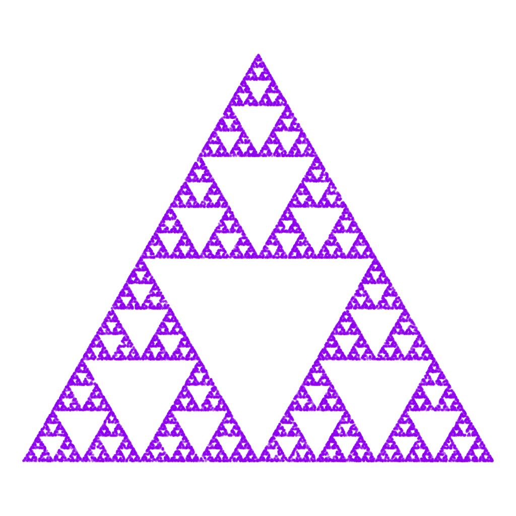

IFS attractor with order-3 rotational symmetry

```r
# Three contractive maps (scale 0.5 toward the vertices)
maps <- list(
  function(p) 0.5 * p + c(0, 0),
  function(p) 0.5 * p + c(0.5, 0),
  function(p) 0.5 * p + c(0.25, sqrt(3) / 4)
)

n <- 25000
pts <- matrix(0, n, 2)
pts[1, ] <- c(0.3, 0.3)

for (i in 2:n) {
  f <- sample(maps, 1)[[1]]
  pts[i, ] <- f(pts[i - 1, ])
}

df <- as.data.frame(pts)
names(df) <- c("x", "y")
ggplot(df, aes(x, y)) +
  geom_point(size = 0.2, alpha = 0.4, color = "purple") +
  coord_fixed() +
  theme_void()
```

# A Simple Design Procedure

1. **Choose the desired symmetry group**  
   Decide on rotational order ( n ) or full dihedral ( D_n ). This is the same vocabulary as Document 1.
2. **Select a fundamental domain**  
   Pick a small set of “seed” points or a basic shape that will be copied by the group actions.
3. **Define contractive maps that respect the group**  
   For each group element ( g ), include a map of the form  
   [ f_g(p) = s g(p) + t ]  
   where ( s < 1 ) is a scale factor and ( t ) is a translation.  
   The collection ( {f_g} ) must be closed under the group action if you want the full symmetry.
4. **Iterate randomly**  
   Start from any point and repeatedly apply a randomly chosen map. After discarding the first few hundred iterates, plot the remaining points (or color by density).
5. **Tune**  
   Adjust scales, translations, and the probability of each map. Small changes produce large visual differences while the symmetry is preserved.

## Example: adding reflections

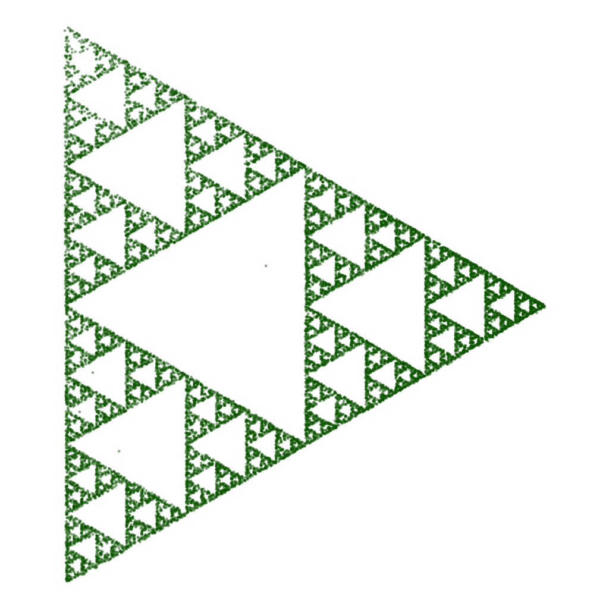

Dihedral version (rotations + reflections)

```r
# Maps that include both rotations and a reflection
reflect <- function(p) c(p[1], -p[2])
base_maps <- list(
  function(p) 0.5 * p + c(0.4, 0),
  function(p) 0.5 * p + c(-0.2, 0.35)
)

n_iter <- 20000
pts <- matrix(0, n_iter, 2)
pts[1, ] <- c(0.1, 0.1)

for (i in 2:n_iter) {
  f <- sample(base_maps, 1)[[1]]
  p <- f(pts[i - 1, ])
  if (runif(1) < 0.5) p <- reflect(p) # randomly apply reflection
  # also rotate by 120° occasionally for order 3
  if (runif(1) < 0.3) {
    th <- 2 * pi / 3
    R <- matrix(c(cos(th), -sin(th), sin(th), cos(th)), 2, 2)
    p <- as.numeric(R %*% p)
  }
  pts[i, ] <- p
}

df <- as.data.frame(pts)
names(df) <- c("x", "y")
ggplot(df, aes(x, y)) +
  geom_point(size = 0.15, alpha = 0.35, color = "darkgreen") +
  coord_fixed() +
  theme_void()
```

# Connection to Classic Fractals

- Sierpinski triangle / carpet → special cases of the above procedure with particular scales and translations.
- Koch curve, dragon curve, etc. can be rewritten as IFS and then symmetrized by adding the group actions.
- The same design steps work whether you are building a deterministic L-system or a random IFS.

Once you have a set of maps that carry a symmetry, every iterate (and therefore the whole attractor) respects that symmetry. That is the bridge from Document 1 into generative fractal design.